# Análise Exploratória I

Jenifer Soares Souza

## Roteiro 02 - Análise Exploratória I

Na Análise Exploratória de Dados, são utilizados métodos para resumir, visualizar e interpretar as principais características dos dados antes de realizar modelagens ou análises complexas.

Considerando o tema escolhido pelo grupo para a disciplina, que envolve dados sobre saneamento, renda e enchentes, parte das informações relacionadas foram extraídas da plataforma Painel Saneamento Brasil para o ano de 2018.

A plataforma Painel Saneamento Brasil é uma iniciativa que visa disponibilizar informações sobre o saneamento básico no Brasil, fornecendo acesso a estatísticas sobre abastecimento de água, esgotamento sanitário, manejo de resíduos sólidos e drenagem urbana, permitindo uma análise das condições de saneamento no país.

### Importando a base de dados

Nesta seção, apresentamos o processo de importação da base de dados relacionada aos indicadores brasileiros para análise utilizando a linguagem R.

Primeiramente, foi feito o download de uma planilha em formato Excel a partir do Painel Saneamento Brasil. Para que os dados pudessem ser lidos no R, foi necessária a instalação do pacote `readxl`.

Após a importação dos dados, utilizamos a função `View()` para visualizar de forma interativa a tabela importada e verificar a estrutura dos dados.

```r
# Importação de biblioteca para leitura de arquivos .xlsx
if (!requireNamespace("readxl", quietly = TRUE)) {
  install.packages("readxl")
}
library(readxl)
# Lendo dados do arquivo que foi feito download
file_path <- "dados_saneamento.xlsx"
data <- read_excel(path = file_path, skip = 2)

View(data)
```

### Explorando os dados

Na sessão anterior, criamos um DataFrame, uma estrutura de dados que organiza informações em linhas e colunas, similar a uma planilha no Excel ou, de forma mais simples, a uma tabela. Cada coluna em um DataFrame possui um cabeçalho que indica qual informação ela representa, fornecendo uma visão dos dados. Para o nosso conjunto de dados, temos:

```r
headers <- paste(names(data), collapse = "\n\n")
cat(headers)
```

```
## Localidade
##
## Parcela da população total que mora em domicílios sem acesso à água tratada
## (% da população) (SNIS)
##
## Parcela da população total que mora em domicílios sem acesso ao serviço de coleta de esgoto
## (% da população) (SNIS)
##
## Volume de esgoto não tratado (água consumida - esgoto tratado)
## (mil m3) (SNIS)
##
## Razão entre volume de esgoto tratado e volume de água consumida
## (%) (SNIS)
##
## Internações por doenças associadas à falta de saneamento
## (Número de internações) (DATASUS)
##
## Óbitos por doenças gastrointestinais infecciosas na população total
## (Número de óbitos) (DATASUS)
##
## Rendimento do trabalho das pessoas que moram em residências com saneamento básico
## (R$ por mês) (IBGE)
##
## Rendimento do trabalho das pessoas que moram em residências sem saneamento
## (R$ por mês) (IBGE)
```

Existem outras formas de visualização de dados, especialmente para fazer verificações rápidas em grandes conjuntos. Uma dessas formas é utilizar a função `head()`, que exibe as primeiras n linhas do nosso DataFrame como saída.

```r
head(data, n = 10)
```

```
## # A tibble: 10 × 9
##    Localidade                Parcela da população total…¹ Parcela da população…²
##    <chr>                     <chr>                        <chr>
##  1 Brasil (0)                0.164                        0.469
##  2 Norte (Região) (1)        0.43                         0.895
##  3 Nordeste (Região) (2)     0.258                        0.72
##  4 Sudeste (Região) (3)      0.09                         0.208
##  5 Sul (Região) (4)          0.098                        0.548
##  6 Centro-Oeste (Região) (5) 0.11                         0.471
##  7 Rondônia (UF) (11)        0.506                        0.951
##  8 Acre (UF) (12)            0.529                        0.899
##  9 Amazonas (UF) (13)        0.189                        0.9
## 10 Roraima (UF) (14)         0.185                        0.483
## # ℹ abbreviated names:
## #   ¹`Parcela da população total que mora em domicílios sem acesso à água tratada\n(% da população) (SNIS)`,
## #   ²`Parcela da população total que mora em domicílios sem acesso ao serviço de coleta de esgoto\n(% da população) (SNIS)`
## # ℹ 6 more variables:
## #   `Volume de esgoto não tratado (água consumida - esgoto tratado)\n(mil m3) (SNIS)` <chr>,
## #   `Razão entre volume de esgoto tratado e volume de água consumida\n(%) (SNIS)` <chr>,
## #   `Internações por doenças associadas à falta de saneamento\n(Número de internações) (DATASUS)` <dbl>, …
```

Da mesma maneira, podemos exibir as últimas n linhas do nosso DataFrame com a função `tail()`.

```r
tail(data, n = 5)
```

```
## # A tibble: 5 × 9
##   Localidade                       Parcela da população…¹ Parcela da população…²
##   <chr>                            <chr>                  <chr>
## 1 Senador Canedo (Município) (522… 0.064                  0.935
## 2 Terezópolis de Goiás (Município… 0.209                  0.399
## 3 Trindade (Município) (522140)    0.0                    0.457
## 4 Valparaíso de Goiás (Município)… 0.0                    0.699
## 5 Brasília (Município) (530010)    0.01                   0.107
## # ℹ abbreviated names:
## #   ¹`Parcela da população total que mora em domicílios sem acesso à água tratada\n(% da população) (SNIS)`,
## #   ²`Parcela da população total que mora em domicílios sem acesso ao serviço de coleta de esgoto\n(% da população) (SNIS)`
## # ℹ 6 more variables:
## #   `Volume de esgoto não tratado (água consumida - esgoto tratado)\n(mil m3) (SNIS)` <chr>,
## #   `Razão entre volume de esgoto tratado e volume de água consumida\n(%) (SNIS)` <chr>,
## #   `Internações por doenças associadas à falta de saneamento\n(Número de internações) (DATASUS)` <dbl>, …
```

Como se pode perceber, os dados apresentam estatísticas que abrangem diferentes níveis geográficos: País (Brasil), regiões (Sul, Sudeste, Centro-Oeste, Norte, Nordeste), estados e municípios. Para esta análise, serão utilizados os dados por município.

Para isso, foram filtradas as linhas que contêm a palavra ‘Município’ em seu nome. Além disso, observou-se que a coluna ‘Localidade’ segue um padrão: Nome da Localidade (Tipo de Localidade) (Código). Para uma melhor representação, ela será dividida em 3 colunas. Nesse processo, foram utilizadas as funções/ferramentas:

- `data.frame()` : usada para criar um novo objeto de dados do tipo.
- `gsub()`: É uma função em R para substituir padrões de texto em uma string, geralmente esse padões são definidos em [REGEX](https://regexr.com/).
- `cbind()`: usada para combinar vetores ou dataframes por coluna.
- `-which(names(data) %in% c("Localidade"))`: o sinal - indica negação, ou seja, estão sendo buscadas as colunas do DataFrame que não a de Localidade.

```r
split_locality <- function(data) {
  data_split <- data.frame(
    Nome = gsub(" \\(.*", "", data$Localidade),
    Tipo = gsub(".*\\((.*?)\\).*", "\\1", data$Localidade),
    Código = gsub(".*\\(|\\)", "", data$Localidade),
    check.names = FALSE
  )

  data_split <- cbind(
    data_split,
    data[, -which(names(data) %in% c("Localidade"))]
  )

  return(data_split)
}


data <- split_locality(data)
View(data)

municipalities_data <- data[grep("Município", data$Tipo), ]
head(municipalities_data)
```

```
##              Nome      Tipo Código
## 55      Ariquemes Município 110002
## 56         Cacoal Município 110004
## 57           Jaru Município 110011
## 58      Ji-Paraná Município 110012
## 59    Porto Velho Município 110020
## 60 Rolim de Moura Município 110028
##    Parcela da população total que mora em domicílios sem acesso à água tratada\n(% da população) (SNIS)
## 55                                                                                                0.087
## 56                                                                                                0.212
## 57                                                                                                0.527
## 58                                                                                                0.336
## 59                                                                                                0.647
## 60                                                                                                0.293
##    Parcela da população total que mora em domicílios sem acesso ao serviço de coleta de esgoto\n(% da população) (SNIS)
```

[output cut: 48 more lines]

A função `str()` exibe a estrutura da base de dados, com a classe da base de dados, o número de observações e variáveis, o nome de cada variável, a classe de cada variável (se é numérica, lógica, caractére ou outra) e as primeiras observações.

```r
str(municipalities_data)
```

```
## 'data.frame':    839 obs. of  11 variables:
##  $ Nome                                                                                                                : chr  "Ariquemes" "Cacoal" "Jaru" "Ji-Paraná" ...
##  $ Tipo                                                                                                                : chr  "Município" "Município" "Município" "Município" ...
##  $ Código                                                                                                              : chr  "110002" "110004" "110011" "110012" ...
##  $ Parcela da população total que mora em domicílios sem acesso à água tratada
## (% da população) (SNIS)                : chr  "0.087" "0.212" "0.527" "0.336" ...
##  $ Parcela da população total que mora em domicílios sem acesso ao serviço de coleta de esgoto
## (% da população) (SNIS): chr  "0.98" "0.493" "1.0" "1.0" ...
##  $ Volume de esgoto não tratado (água consumida - esgoto tratado)
## (mil m3) (SNIS)                                     : chr  "2822.11" "2691.01" "992.84" "4039.43" ...
##  $ Razão entre volume de esgoto tratado e volume de água consumida
## (%) (SNIS)                                         : chr  "0.043" "0.39" "-" "-" ...
##  $ Internações por doenças associadas à falta de saneamento
## (Número de internações) (DATASUS)                         : num  124 156 80 183 407 193 214 155 83 5 ...
##  $ Óbitos por doenças gastrointestinais infecciosas na população total
## (Número de óbitos) (DATASUS)                   : num  0 1 0 2 9 2 2 1 2 0 ...
##  $ Rendimento do trabalho das pessoas que moram em residências com saneamento básico
## (R$ por mês) (IBGE)              : num  2964 3525 4324 5732 3319 ...
##  $ Rendimento do trabalho das pessoas que moram em residências sem saneamento
## (R$ por mês) (IBGE)                     : num  1087 804 1049 800 1076 ...
```

A função `summary()` apresenta um sumário de estatísticas descritivas (mínimo, 1º quartil, mediana, média, 3º quartil, máximo e valores faltantes - NA’s) para todas as variáveis numéricas.

```r
summary(municipalities_data)
```

```
##      Nome               Tipo              Código
##  Length:839         Length:839         Length:839
##  Class :character   Class :character   Class :character
##  Mode  :character   Mode  :character   Mode  :character
##
##
##
##  Parcela da população total que mora em domicílios sem acesso à água tratada\n(% da população) (SNIS)
##  Length:839
##  Class :character
##  Mode  :character
##
##
##
##  Parcela da população total que mora em domicílios sem acesso ao serviço de coleta de esgoto\n(% da população) (SNIS)
##  Length:839
##  Class :character
##  Mode  :character
##
##
##
##  Volume de esgoto não tratado (água consumida - esgoto tratado)\n(mil m3) (SNIS)
##  Length:839
##  Class :character
##  Mode  :character
##
##
##
##  Razão entre volume de esgoto tratado e volume de água consumida\n(%) (SNIS)
##  Length:839
##  Class :character
##  Mode  :character
##
##
##
##  Internações por doenças associadas à falta de saneamento\n(Número de internações) (DATASUS)
##  Min.   :   0.0
##  1st Qu.:  15.0
##  Median :  40.0
##  Mean   : 104.5
```

[output cut: 8 more lines]

```
##  Max.   :84.00
##  Rendimento do trabalho das pessoas que moram em residências com saneamento básico\n(R$ por mês) (IBGE)
##  Min.   :  618.8
##  1st Qu.: 1832.5
##  Median : 2340.0
##  Mean   : 2495.4
##  3rd Qu.: 2898.7
##  Max.   :10946.9
##  Rendimento do trabalho das pessoas que moram em residências sem saneamento\n(R$ por mês) (IBGE)
##  Min.   : 116.7
##  1st Qu.: 634.3
##  Median : 892.6
##  Mean   : 926.7
##  3rd Qu.:1161.3
##  Max.   :2790.7
```

### Criando subconjuntos

No decorrer de uma análise de dados, você pode precisar selecionar variáveis e filtrar observações, ou seja criar um subconjunto. Na linguagem R, subconjuntos podem ser criados com o uso de colchetes, seguindo o formato: `base_da_dados[observações,variáveis]`.

Por exemplo, é possível selecionar as seis primeiras observações, de forma similar à função `head()`, com o comando:

```r
municipalities_data[1:6,]
```

```
##              Nome      Tipo Código
## 55      Ariquemes Município 110002
## 56         Cacoal Município 110004
## 57           Jaru Município 110011
## 58      Ji-Paraná Município 110012
## 59    Porto Velho Município 110020
## 60 Rolim de Moura Município 110028
##    Parcela da população total que mora em domicílios sem acesso à água tratada\n(% da população) (SNIS)
## 55                                                                                                0.087
## 56                                                                                                0.212
## 57                                                                                                0.527
## 58                                                                                                0.336
## 59                                                                                                0.647
## 60                                                                                                0.293
##    Parcela da população total que mora em domicílios sem acesso ao serviço de coleta de esgoto\n(% da população) (SNIS)
```

[output cut: 48 more lines]

Para visualizar apenas o nome dos municípios, podemos adicionar um segundo argumento com o número ou nome da variável:

```r
municipalities_data[1:6, 1]
```

```
## [1] "Ariquemes"      "Cacoal"         "Jaru"           "Ji-Paraná"
## [5] "Porto Velho"    "Rolim de Moura"
```

```r
municipalities_data[1:6, "Nome"]
```

```
## [1] "Ariquemes"      "Cacoal"         "Jaru"           "Ji-Paraná"
## [5] "Porto Velho"    "Rolim de Moura"
```

Outra forma de acessar uma coluna pelo seu nome é usando o operador `$` (cifrão) após os colchetes.

```r
municipalities_data[1:6,]$Nome
```

```
## [1] "Ariquemes"      "Cacoal"         "Jaru"           "Ji-Paraná"
## [5] "Porto Velho"    "Rolim de Moura"
```

Para ver o nome do município e código, podemos adicionar um vetor no segundo argumento com as variáveis de interesse:

```r
municipalities_data[1:6, c("Nome", "Código")]
```

```
##              Nome Código
## 55      Ariquemes 110002
## 56         Cacoal 110004
## 57           Jaru 110011
## 58      Ji-Paraná 110012
## 59    Porto Velho 110020
## 60 Rolim de Moura 110028
```

```r
municipalities_data[
  which(
    grepl("^M", municipalities_data$Nome) &
    municipalities_data[, 8] > 100
  ),
  c("Nome", "Internações por doenças associadas à falta de saneamento
(Número de internações) (DATASUS)")
]
```

```
##              Nome
## 69     Manacapuru
## 70         Manaus
## 103      Marituba
## 104          Moju
## 126        Macapá
## 203     Maracanaú
## 205   Morada Nova
## 296        Maceió
## 424       Mariana
## 429 Montes Claros
## 881      Mineiros
##     Internações por doenças associadas à falta de saneamento\n(Número de internações) (DATASUS)
## 69                                                                                          161
## 70                                                                                         1604
## 103                                                                                         284
## 104                                                                                         136
## 126                                                                                         315
## 203                                                                                         109
## 205                                                                                         109
## 296                                                                                         456
## 424                                                                                         139
## 429                                                                                         119
## 881                                                                                         193
```

### Definindo uma nova variável

```r
municipalities_data$"Teve Internações" <- ifelse(
  municipalities_data$"Internações por doenças associadas à falta de saneamento
(Número de internações) (DATASUS)" > 0,
  "Sim",
  "Não"
)

head(municipalities_data)
```

```
##              Nome      Tipo Código
## 55      Ariquemes Município 110002
## 56         Cacoal Município 110004
## 57           Jaru Município 110011
## 58      Ji-Paraná Município 110012
## 59    Porto Velho Município 110020
## 60 Rolim de Moura Município 110028
##    Parcela da população total que mora em domicílios sem acesso à água tratada\n(% da população) (SNIS)
## 55                                                                                                0.087
## 56                                                                                                0.212
## 57                                                                                                0.527
## 58                                                                                                0.336
## 59                                                                                                0.647
## 60                                                                                                0.293
##    Parcela da população total que mora em domicílios sem acesso ao serviço de coleta de esgoto\n(% da população) (SNIS)
```

[output cut: 55 more lines]

### Calculando estatísticas básicas (média, mediana, variância, desvio padrão)

Em todas as funções usaremos o argumento opcional `na.rm = TRUE` para remover os valores faltantes (NA). Se a variável não possuir valores faltantes, esse argumento não é necessário.

A média é uma medida estatística de tendência central que representa o centro de massa de uma distribuição contínua. É calculada somando todos os valores e dividindo o resultado pelo número total de observações.

```r
indexes <- 8:11

means <- colMeans(municipalities_data[, indexes], na.rm = TRUE)
means_df <- data.frame(
  "Média" = means
)

means_df
```

```
##                                                                                                             Média
## Internações por doenças associadas à falta de saneamento\n(Número de internações) (DATASUS)             104.53397
## Óbitos por doenças gastrointestinais infecciosas na população total\n(Número de óbitos) (DATASUS)         1.61025
## Rendimento do trabalho das pessoas que moram em residências com saneamento básico\n(R$ por mês) (IBGE) 2495.38026
## Rendimento do trabalho das pessoas que moram em residências sem saneamento\n(R$ por mês) (IBGE)         926.67825
```

A mediana é uma medida estatística de tendência central que representa o valor central de um conjunto de dados ordenados numericamente. Para encontrar a mediana, os dados são organizados em ordem crescente ou decrescente, e a mediana é o valor que está exatamente no meio da distribuição, ou a média dos dois valores centrais.

```r
medians <- apply(municipalities_data[, indexes], 2, median, na.rm = TRUE)
medians_df <- data.frame(
  "Mediana" = medians
)

medians_df
```

```
##                                                                                                        Mediana
## Internações por doenças associadas à falta de saneamento\n(Número de internações) (DATASUS)              40.00
## Óbitos por doenças gastrointestinais infecciosas na população total\n(Número de óbitos) (DATASUS)         1.00
## Rendimento do trabalho das pessoas que moram em residências com saneamento básico\n(R$ por mês) (IBGE) 2340.04
## Rendimento do trabalho das pessoas que moram em residências sem saneamento\n(R$ por mês) (IBGE)         892.61
```

A variância é uma medida estatística de espalhamento que indica a dispersão dos dados em relação à média. Ela calcula a média dos quadrados das diferenças entre cada observação e a média.

```r
vars <- apply(municipalities_data[, indexes], 2, var, na.rm = TRUE)
vars_df <- data.frame(
  "Variância" = vars
)

vars_df
```

```
##                                                                                                           Variância
## Internações por doenças associadas à falta de saneamento\n(Número de internações) (DATASUS)            7.094293e+04
## Óbitos por doenças gastrointestinais infecciosas na população total\n(Número de óbitos) (DATASUS)      1.728347e+01
## Rendimento do trabalho das pessoas que moram em residências com saneamento básico\n(R$ por mês) (IBGE) 1.065697e+06
## Rendimento do trabalho das pessoas que moram em residências sem saneamento\n(R$ por mês) (IBGE)        1.664342e+05
```

O desvio padrão é uma medida estatística de espalhamento que quantifica a dispersão dos valores em um conjunto de dados em relação à média. Ele é a raiz quadrada da variância.

```r
sds <- apply(municipalities_data[, indexes], 2, sd, na.rm = TRUE)
sds_df <- data.frame(
  "Desvio Padrão" = sds
)

sds_df
```

```
##                                                                                                        Desvio.Padrão
## Internações por doenças associadas à falta de saneamento\n(Número de internações) (DATASUS)                266.35113
## Óbitos por doenças gastrointestinais infecciosas na população total\n(Número de óbitos) (DATASUS)            4.15734
## Rendimento do trabalho das pessoas que moram em residências com saneamento básico\n(R$ por mês) (IBGE)    1032.32610
## Rendimento do trabalho das pessoas que moram em residências sem saneamento\n(R$ por mês) (IBGE)            407.96343
```

### Desenhando gráficos

#### Box-plot

Um gráfico Boxplot, ou diagrama de caixa, é uma ferramenta visual utilizada para representar a distribuição de um conjunto de dados através de quartis, além de sua mediana e limites superior e inferior.

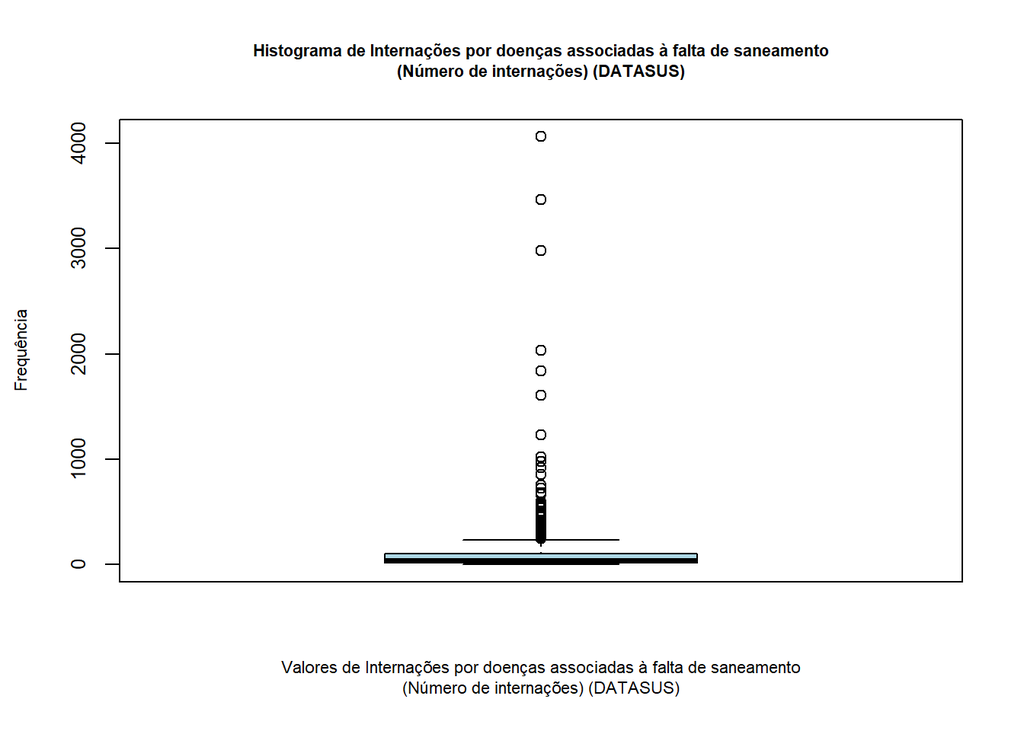

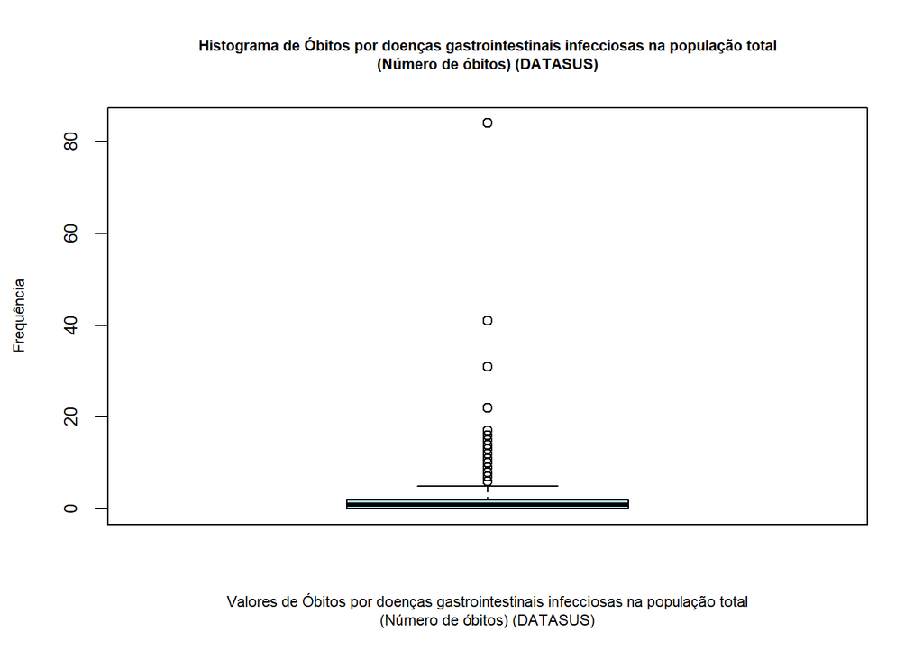

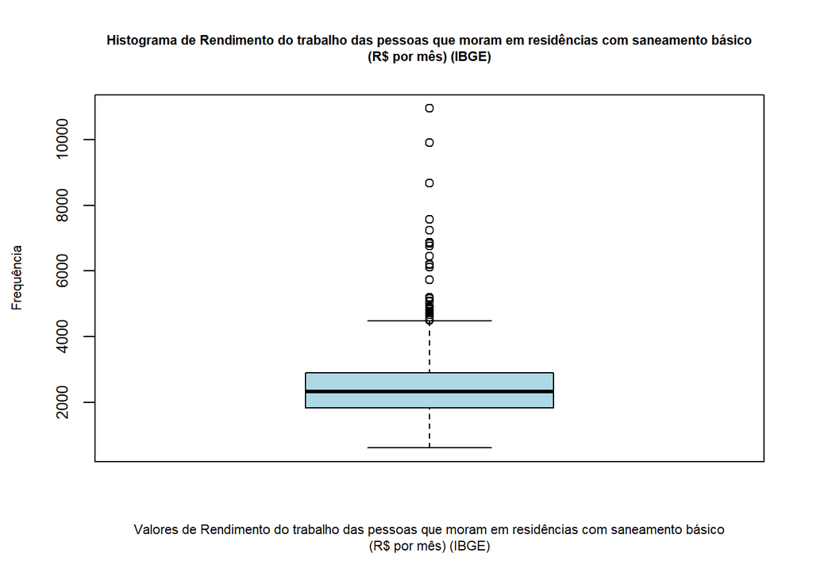

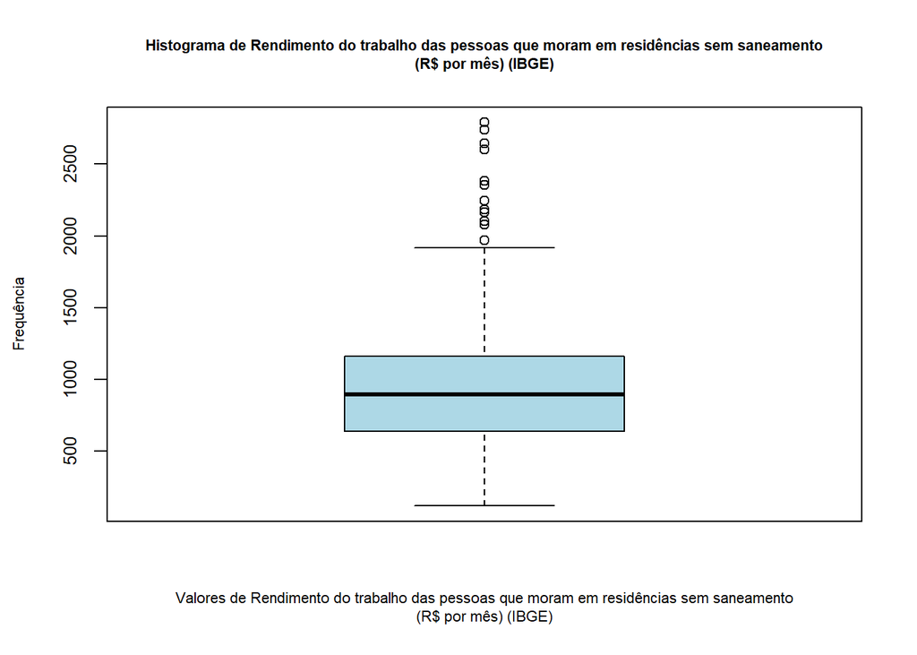

```r
for (index in indexes) {
  col <- names(municipalities_data)[index]
  main_title <- paste("Histograma de", col)

  boxplot(
    municipalities_data[[index]],
    main = main_title,
    xlab = paste("Valores de", col),
    ylab = "Frequência",
    col = "lightblue",
    cex.main = 0.7,
    cex.lab = 0.7,
    cex.axis = 0.8
  )
}
```

O box-plot das colunas selecionadas indica que existem diversos valores atípicos (*outliers*), ou seja, fora dos limites.

#### Histograma

Um histograma é um tipo de gráfico utilizado para representar a distribuição de frequência da ocorrência de uma observação em um conjunto de dados.

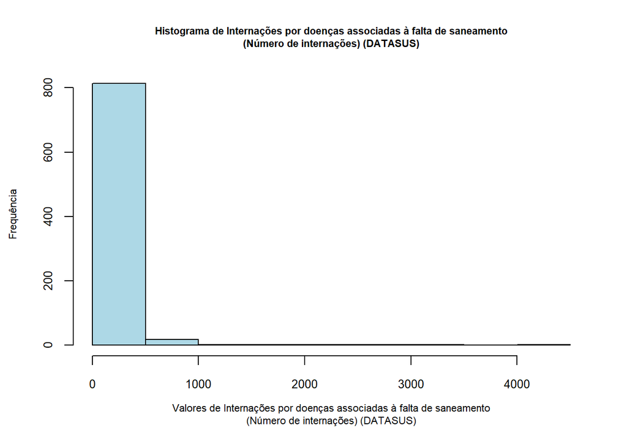

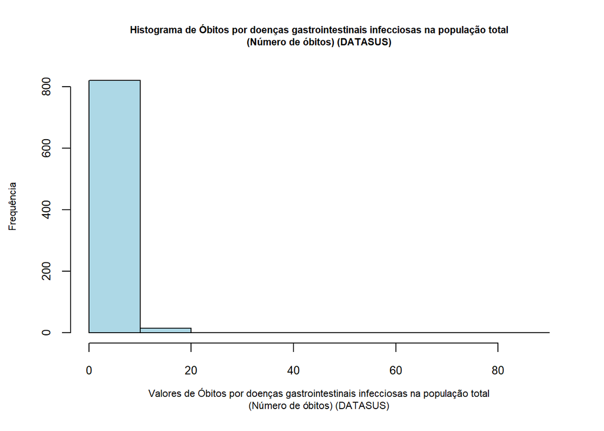

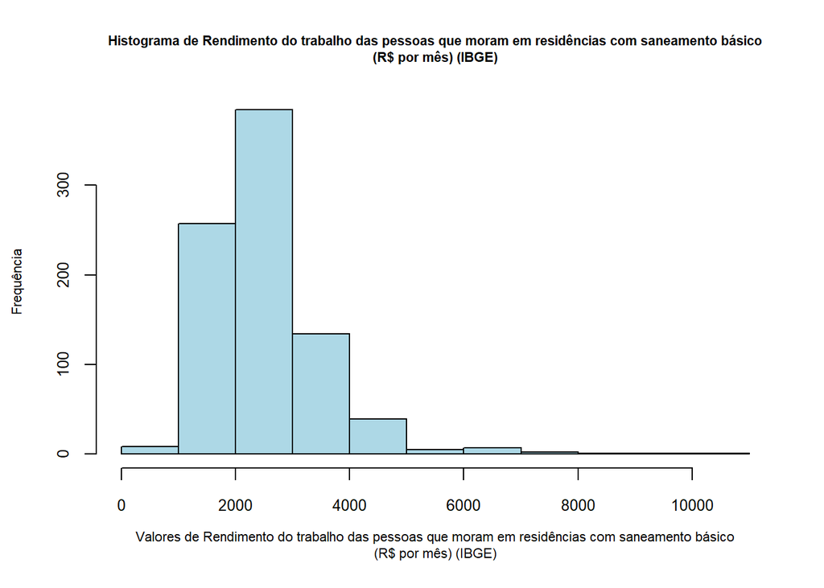

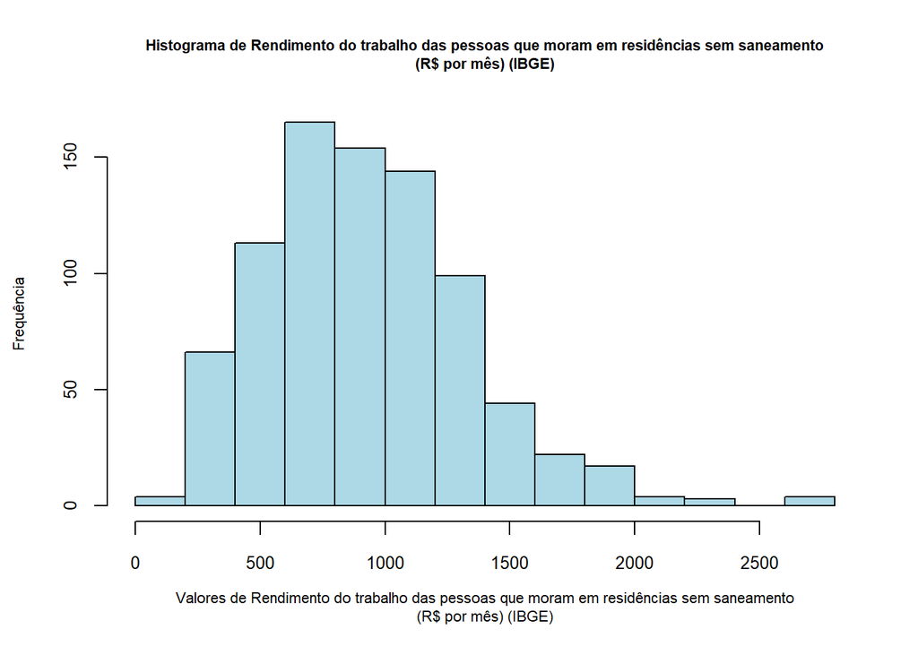

```r
for (index in indexes) {
  col <- names(municipalities_data)[index]
  main_title <- paste("Histograma de", col)

  hist(
    municipalities_data[[index]],
    main = main_title,
    xlab = paste("Valores de", col),
    ylab = "Frequência",
    col = "lightblue",
    cex.main = 0.7,
    cex.lab = 0.7,
    cex.axis = 0.8
  )
}
```

Ao analisar os histogramas, observa-se uma assimetria e a divergência entre média, mediana e moda, indicando que as distribuições das colunas selecionadas não seguem uma distribuição normal.

#### Qqplot

qqplot é um gráfico usado para avaliar se um conjunto de dados segue ou não um tipo de distribuição, como por exemplo, a distribuição normal.

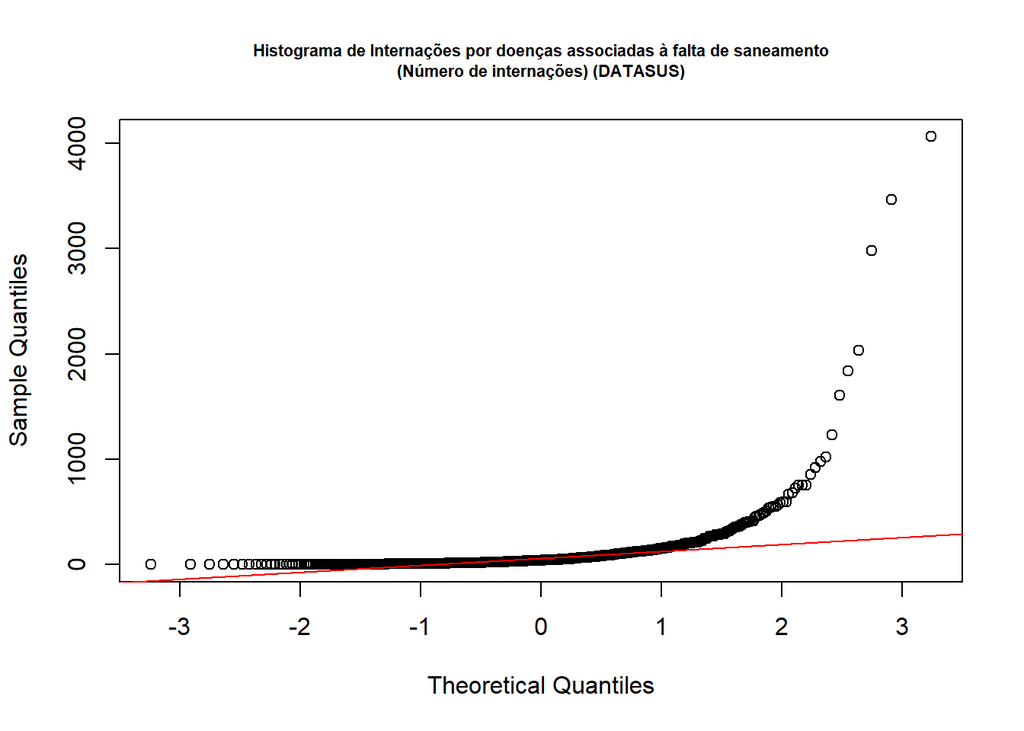

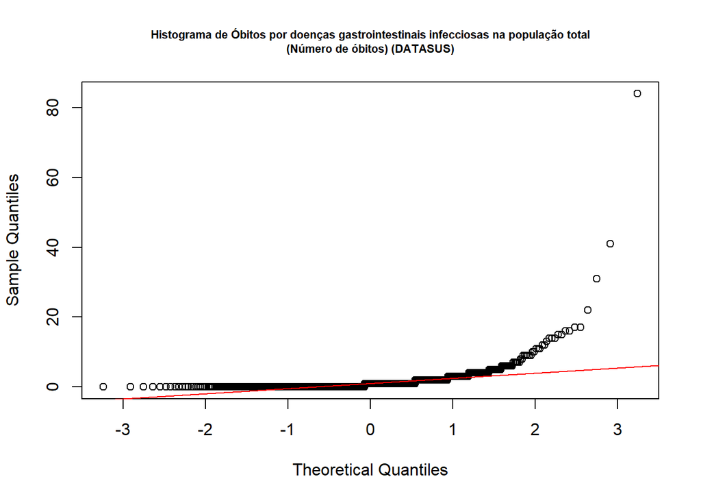

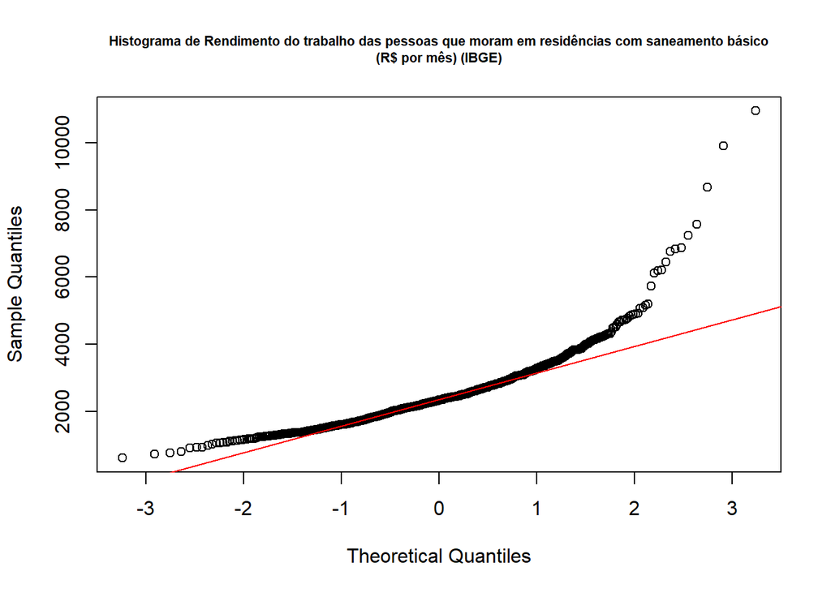

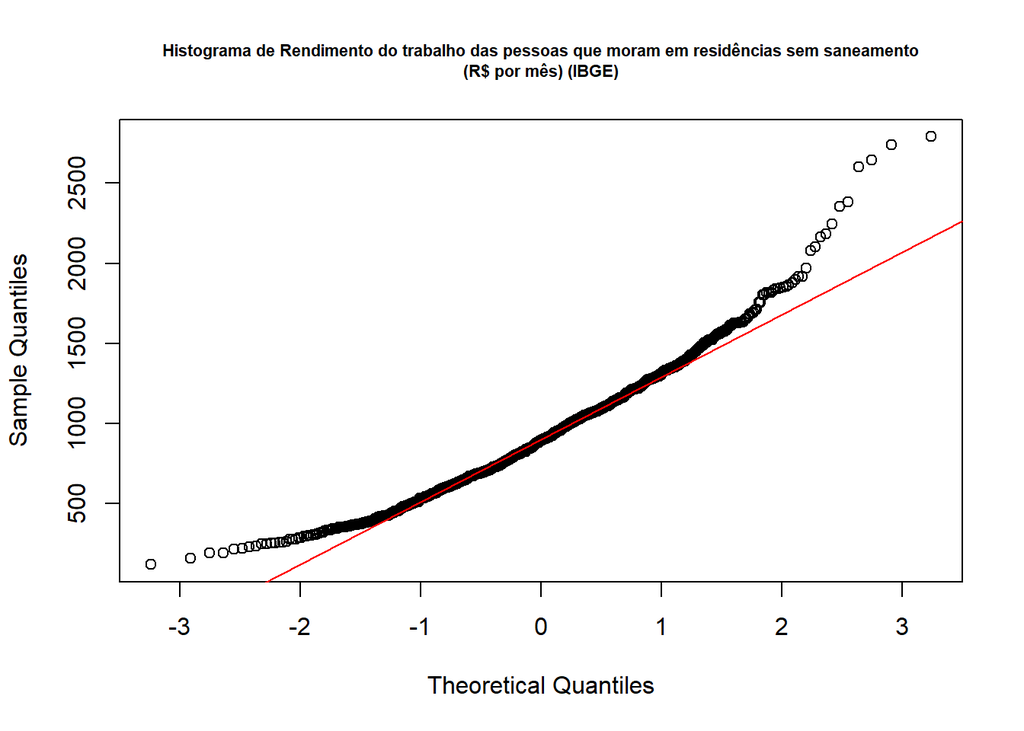

```r
for (index in indexes) {
  col <- names(municipalities_data)[index]
  main_title <- paste("Histograma de", col)

  qqnorm(municipalities_data[[index]], main = main_title, cex.main = 0.7,)
  qqline(municipalities_data[[index]], col = "red")
}
```

O qqplot das colunas selecionadas sugere uma certa linearidade pela proximidade com a curva normal (em vermelho) nos quantis centrais, desviando da curva em valores muito altos e muito baixos (*outliers*).

### Exportando a base de dados

Após executar a rotina, é recomendado que o usuário salve as alterações feitas na base de dados para acesso futuro. Para exportar os dados, o procedimento envolve utilizar a biblioteca `openxlsx`.

É possível exportar o dataframe para um arquivo Excel (.xlsx) usando a função `write.xlsx(dataframe, file = "nome_do_arquivo.xlsx")`.

```r
if (!requireNamespace("openxlsx", quietly = TRUE)) {
  install.packages("openxlsx")
}
library(openxlsx)
output_file_path <- "dados_saneamento_v2.xlsx"
write.xlsx(municipalities_data, file = output_file_path)
```

** Essa aula foi baseada em: https://github.com/luisfelipebr/mti2020/blob/master/roteiros/roteiro2.Rmd. E os arquivos gerados podem ser visualizados em: https://github.com/jeniferss/ESHT011-21_ADPPT/tree/main/semana_02